# DragRaceUk

Emily Nordmann

23/10/2019

This analysis uses the package rtweet to collect tweets containing the #DragRaceUK hashtag - there is a good tutorial [here](https://rtweet.info/) if you want more information.

```r
library(rtweet)
library(tidytext)
library(tidyverse)
library(gridExtra)
library(lubridate)


# get tweets with the #DragRaceUK hashtag

tweets <- search_tweets(
  "#DragRaceUK", n = 18000, include_rts = FALSE)

# get rid of numbers, links, and the hashtags then select timestamp and text columns

dat <- tweets %>%
  mutate(text = str_replace_all(text, "[^\x01-\x7F]", ""),
         text = str_replace_all(text, "#DragRaceUK", ""),
         text = str_replace_all(text, "DragRace", ""),
         text = str_replace_all(text, "dragrace", ""),
         text = str_replace_all(text, "\\.|[[:digit:]]+", ""),
         text = str_replace_all(text, "https|amp|tco", ""))%>%
  select(created_at, text)%>%
  mutate(tweet = row_number())

# write.csv(x = dat, file = "#DragRaceUK tweets 2019-10-23.csv")

# create tidy text

dat_token <- dat %>%
  unnest_tokens(word, text) %>%
  anti_join(stop_words, by = "word")

# convert tidy text back to wide so that all in lower case etc.

dat_lower <- dat_token %>%
  group_by(tweet) %>%
  summarise(text = str_c(word, collapse = " "))

# add in column to say if each queen mentioned in tweet

dat_lower <- dat_lower %>%
  mutate(baga = case_when(str_detect(text, ".baga") ~ TRUE, TRUE ~ FALSE),
         blu = case_when(str_detect(text, ".blu") ~ TRUE, TRUE ~ FALSE),
         divina = case_when(str_detect(text, ".divina") ~ TRUE, TRUE ~ FALSE),
         crystal = case_when(str_detect(text, ".crystal") ~ TRUE, TRUE ~ FALSE),
         sum = case_when(str_detect(text, ".sum") ~ TRUE, TRUE ~ FALSE),
         cheryl = case_when(str_detect(text, ".cheryl") ~ TRUE, TRUE ~ FALSE),
         gothy = case_when(str_detect(text, ".gothy") ~ TRUE, TRUE ~ FALSE),
         vinegar = case_when(str_detect(text, ".vinegar") ~ TRUE, TRUE ~ FALSE),
         scaredy = case_when(str_detect(text, ".scaredy") ~ TRUE, TRUE ~ FALSE),
         vivienne = case_when(str_detect(text, ".vivienne") ~ TRUE, TRUE ~ FALSE)
  )

# create tidy text with the mention columns

dat_mentions <- dat_lower %>%
  unnest_tokens(word, text) %>%
  anti_join(stop_words, by = "word")
```

The first plot looks at the raw number of tweets that mention each Queen. This isn’t a perfect measure because it relies upon people on Twitter spelling the names correctly and people on the internet can’t spell, however, it has some face validity.

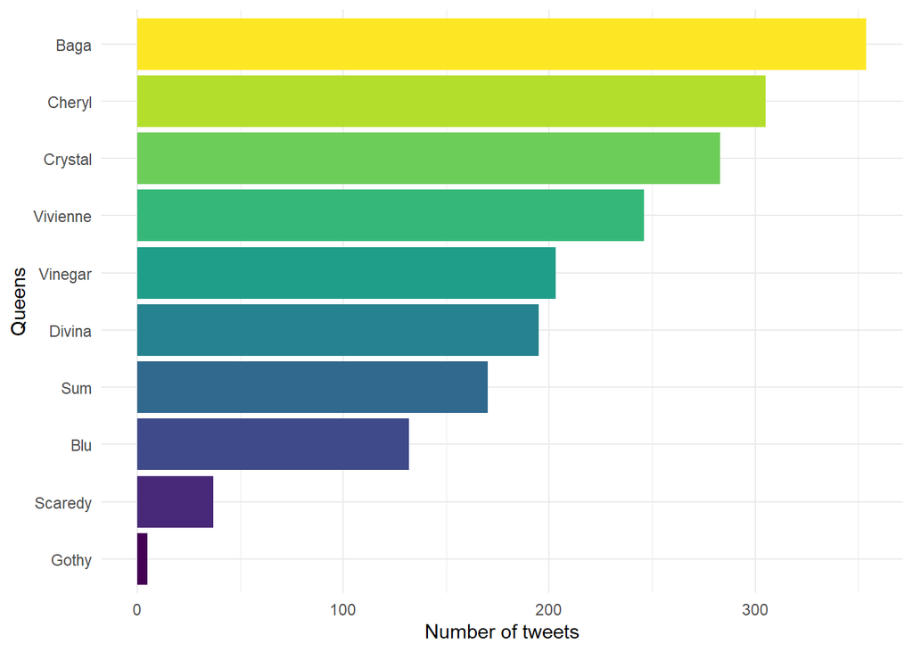

```r
dat_token %>%
  filter(word %in% c("baga", "blu", "divina", "crystal", "sum", "cheryl",
                     "gothy", "vinegar", "scaredy", "vivienne"))%>%
  count(word, sort = TRUE) %>%
  head(20) %>%
  mutate(word = str_to_title(word),
         word = reorder(word, n))%>%
  ggplot(aes(x = word, y = n, fill = word)) +
  geom_col(show.legend = FALSE) +
  coord_flip()+
  scale_y_continuous(name = "Number of tweets")+
  scale_x_discrete(name = "Queens") +
  theme_minimal() +
  scale_fill_viridis_d()
```

The next lot of code runs a sentiment analysis on the tweets that each Queen is mentioned in. Sentiment analyses using existing ratings of words (e.g., if they’re positive or negative) to give you a sense of whether the queen is being mentioned in a tweet that is overall positive or negative in tone. Again it’s not perfect, it can’t cope with slang (e.g., it will think that a sickening death drop is a bad thing), but it does have face validity.

What this shows is that even though Divina isn’t mentioned as much a Baga, the tweets she is mentioned in contain more positive words than negative words.

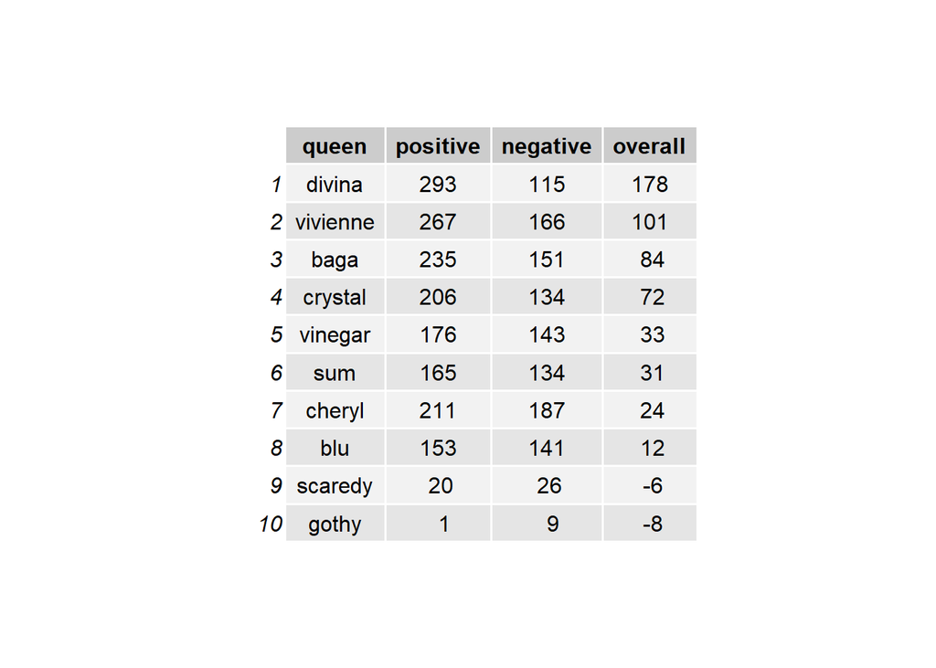

```r
# do a sentiment analysis for each queen

baga <- dat_mentions %>%
  filter(baga == "TRUE")%>%
  inner_join(get_sentiments("bing"))%>%
  count(index = tweet, sentiment) %>%
  spread(sentiment, n, fill = 0) %>%
  mutate(sentiment = positive - negative)%>%
  mutate(queen = "baga")

cheryl <- dat_mentions %>%
  filter(cheryl == "TRUE")%>%
  inner_join(get_sentiments("bing"))%>%
  count(index = tweet, sentiment) %>%
  spread(sentiment, n, fill = 0) %>%
  mutate(sentiment = positive - negative)%>%
  mutate(queen = "cheryl")

crystal <- dat_mentions %>%
  filter(crystal == "TRUE")%>%
  inner_join(get_sentiments("bing"))%>%
  count(index = tweet, sentiment) %>%
  spread(sentiment, n, fill = 0) %>%
  mutate(sentiment = positive - negative)%>%
  mutate(queen = "crystal")

vivienne <- dat_mentions %>%
  filter(vivienne == "TRUE")%>%
  inner_join(get_sentiments("bing"))%>%
  count(index = tweet, sentiment) %>%
  spread(sentiment, n, fill = 0) %>%
  mutate(sentiment = positive - negative)%>%
  mutate(queen = "vivienne")

vinegar <- dat_mentions %>%
  filter(vinegar == "TRUE")%>%
  inner_join(get_sentiments("bing"))%>%
  count(index = tweet, sentiment) %>%
  spread(sentiment, n, fill = 0) %>%
  mutate(sentiment = positive - negative)%>%
  mutate(queen = "vinegar")

divina <- dat_mentions %>%
  filter(divina == "TRUE")%>%
  inner_join(get_sentiments("bing"))%>%
  count(index = tweet, sentiment) %>%
  spread(sentiment, n, fill = 0) %>%
  mutate(sentiment = positive - negative)%>%
  mutate(queen = "divina")

sum <- dat_mentions %>%
  filter(sum == "TRUE")%>%
  inner_join(get_sentiments("bing"))%>%
  count(index = tweet, sentiment) %>%
  spread(sentiment, n, fill = 0) %>%
  mutate(sentiment = positive - negative)%>%
  mutate(queen = "sum")

blu <- dat_mentions %>%
  filter(blu == "TRUE")%>%
  inner_join(get_sentiments("bing"))%>%
  count(index = tweet, sentiment) %>%
  spread(sentiment, n, fill = 0) %>%
  mutate(sentiment = positive - negative)%>%
  mutate(queen = "blu")

scaredy <- dat_mentions %>%
  filter(scaredy == "TRUE")%>%
  inner_join(get_sentiments("bing"))%>%
  count(index = tweet, sentiment) %>%
  spread(sentiment, n, fill = 0) %>%
  mutate(sentiment = positive - negative)%>%
  mutate(queen = "scaredy")

gothy <- dat_mentions %>%
  filter(gothy == "TRUE")%>%
  inner_join(get_sentiments("bing"))%>%
  count(index = tweet, sentiment) %>%
  spread(sentiment, n, fill = 0) %>%
  mutate(sentiment = positive - negative)%>%
  mutate(queen = "gothy")

# combine sentiment analysis for each queen into one tibble and then calculate total positive, negative
# and overall sentimment scores for each queen

dat_sentiment <- bind_rows(baga, cheryl, crystal, vivienne, vinegar, divina, sum, blu, scaredy, gothy) %>%
  group_by(queen) %>%
  summarise(positive = sum(positive),
            negative = sum(negative),
            overall = sum(sentiment))%>%
  gather(positive:overall, key = type, value = score)%>%
  mutate(type = factor(type, levels = c("positive", "negative", "overall")))%>%
  mutate(queen = factor(queen, levels = c("baga", "blu", "divina", "crystal", "sum", "cheryl",
                                          "gothy", "vinegar", "scaredy", "vivienne")))

# display table of sentiment scores

tbl <- dat_sentiment %>%
  spread(type, score)%>%
  arrange(desc(overall))

grid.table(tbl)
```